# Lake Report

[Lake Report (500615)](https://governmentofbc.maps.arcgis.com/apps/MapSeries/index.html?appid=a5ffb1bcffad4407b387292f2e55899f) is located at SKAHA L OPP. GILLIES. Report generated: November 25, 2026.

The plot below shows the sampling history at this site. Composite samples are indicated by a vertical line connecting the uppermost and lowermost sampling depths. Triangles (▲) indicate epilimnion (upper layer) samples; solid circles (●) indicate hypolimnion (bottom layer) samples. For lakes less than 10 m deep, a single sample 1 m below the surface represents the epilimnion and one 1 m off the bottom represents the hypolimnion.

To read more about the B.C. Lakes Monitoring Network (BCLMN) go [here](https://www2.gov.bc.ca/gov/content?id=2493EFF1E42747E1904540DA4D2CF9DD).

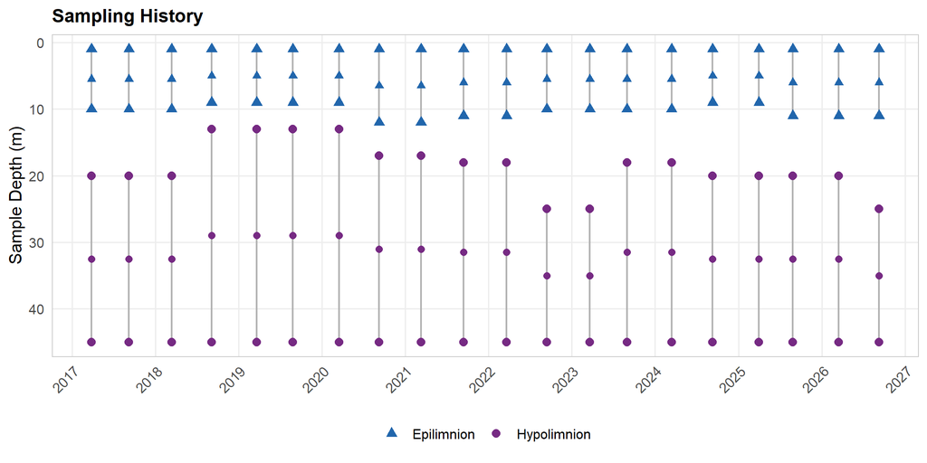

Sampling dates and depth ranges

### Water Quality Trend Summary

The table below gives an at-a-glance summary of every parameter analysed at this site: whether a statistically significant trend (p < 0.05) was detected in each depth/season group, and the applicable BC Aquatic Life guideline. Click a row’s parameter name in the tabs below to see the full plot and history.

**Summary table of trend results**

| Category | Parameter | Epilimnion Spring | Epilimnion Summer | Hypolimnion Spring | Hypolimnion Summer | Guideline |
| --- | --- | --- | --- | --- | --- | --- |
| Field | **Dissolved Oxygen-Field (fl. conc.)** | — no trend | — no trend | n/a | n/a | ≥ 8 mg/L |
| Field | **Extinction Depth (len.)** | ▼ 3.5%/yr | ▼ 8.5%/yr | n/a | n/a | — |
| Field | **Specific Conductivity-Field (elec. cond.)** | — no trend | — no trend | n/a | n/a | — |
| Field | **Temperature-Field (temp.)** | — no trend | — no trend | n/a | n/a | — |
| Field | **pH-Field (acidity)** | — no trend | — no trend | n/a | n/a | — |
| General | **Carbon Dissolved Organic (fl. conc.)** | — no trend | — no trend | — no trend | — no trend | — |
| General | **Carbon Total Organic (fl. conc.)** | — no trend | ▲ 1.6%/yr | — no trend | — no trend | — |
| General | **Chlorophyll A (fl. conc.)** | — no trend | ▲ 18.7%/yr | n/a | n/a | — |
| General | **Specific Conductance (elec. cond.)** | — no trend | — no trend | — no trend | — no trend | — |
| General | **Turbidity (turb.)** | — no trend | ▲ 28.4%/yr | — no trend | — no trend | — |
| General | **pH (acidity)** | — no trend | — no trend | — no trend | — no trend | — |
| Major Ions | **Chloride Dissolved (fl. conc.)** | ▲ 3.5%/yr | ▲ 3.7%/yr | ▲ 3.5%/yr | ▲ 4.0%/yr | ≤ 150 mg/L |
| Major Ions | **Hardness Total (Total) (fl. conc.)** | — no trend | — no trend | — no trend | — no trend | — |
| Major Ions | **Sulfate Dissolved (fl. conc.)** | — no trend | — no trend | — no trend | — no trend | — |
| Nutrients | **Nitrate (NO3) Dissolved (fl. conc.)** | — no trend | — no trend | — no trend | — no trend | ≤ 3 mg/L |
| Nutrients | **Nitrate(NO3) + Nitrite(NO2) Dissolved (fl. conc.)** | — no trend | — no trend | — no trend | — no trend | — |
| Nutrients | **Nitrogen - Nitrite Dissolved (NO2) (fl. conc.)** | — no trend | — no trend | — no trend | — no trend | — |
| Nutrients | **Nitrogen Ammonia Total (fl. conc.)** | — no trend | — no trend | — no trend | — no trend | — |
| Nutrients | **Nitrogen Kjel.Tot(N) (fl. conc.)** | — no trend | — no trend | — no trend | — no trend | — |
| Nutrients | **Nitrogen Organic-Total (fl. conc.)** | — no trend | — no trend | — no trend | — no trend | — |
| Nutrients | **Nitrogen Total (fl. conc.)** | — no trend | — no trend | — no trend | — no trend | — |
| Nutrients | **Phosphorus Ort.Dis-P (fl. conc.)** | — no trend | — no trend | — no trend | ▲ 19.6%/yr | — |
| Nutrients | **Phosphorus Total (fl. conc.)** | ▲ 13.7%/yr | — no trend | ▲ 14.2%/yr | ▲ 14.6%/yr | ≤ 15 ug/L |
| Nutrients | **Phosphorus Total Dissolved (fl. conc.)** | ▲ 16.4%/yr | — no trend | — no trend | ▲ 15.6%/yr | — |
| Nutrients | **Silica Reactive Diss (fl. conc.)** | — no trend | ▼ 2.9%/yr | ▼ 3.5%/yr | — no trend | — |
| Metals - Total | **Aluminum Total (fl. conc.)** | ▼ 12.8%/yr | — no trend | ▼ 18.2%/yr | — no trend | — |
| Metals - Total | **Antimony Total (fl. conc.)** | — no trend | — no trend | ▼ 1.8%/yr | — no trend | ≤ 74 ug/L |
| Metals - Total | **Arsenic Total (fl. conc.)** | — no trend | — no trend | — no trend | ▲ 2.3%/yr | ≤ 5 ug/L |
| Metals - Total | **Barium Total (fl. conc.)** | — no trend | — no trend | — no trend | — no trend | ≤ 1 mg/L |
| Metals - Total | **Beryllium Total (fl. conc.)** | — no trend | — no trend | — no trend | — no trend | ≤ 0.13 ug/L |
| Metals - Total | **Bismuth Total (fl. conc.)** | — no trend | — no trend | — no trend | — no trend | — |
| Metals - Total | **Boron Total (fl. conc.)** | ▲ 1.4%/yr | — no trend | — no trend | ▲ 2.0%/yr | ≤ 1.2 mg/L |
| Metals - Total | **Cadmium Total (fl. conc.)** | — no trend | — no trend | — no trend | — no trend | — |
| Metals - Total | **Calcium Total (fl. conc.)** | — no trend | — no trend | — no trend | — no trend | — |
| Metals - Total | **Chromium Total (fl. conc.)** | — no trend | — no trend | — no trend | — no trend | — |
| Metals - Total | **Cobalt Total (fl. conc.)** | ▲ 2.9%/yr | ▲ 4.1%/yr | — no trend | — no trend | — |
| Metals - Total | **Copper Total (fl. conc.)** | — no trend | ▲ 5.4%/yr | — no trend | — no trend | — |
| Metals - Total | **Iron Total (fl. conc.)** | ▼ 5.2%/yr | ▼ 6.3%/yr | ▼ 7.4%/yr | ▼ 8.3%/yr | — |
| Metals - Total | **Lead Total (fl. conc.)** | — no trend | — no trend | ▼ 14.0%/yr | — no trend | — |
| Metals - Total | **Lithium Total (fl. conc.)** | — no trend | — no trend | — no trend | — no trend | — |
| Metals - Total | **Magnesium Total (fl. conc.)** | — no trend | — no trend | — no trend | — no trend | — |
| Metals - Total | **Manganese Total (fl. conc.)** | ▲ 8.3%/yr | ▼ 6.1%/yr | — no trend | — no trend | — |
| Metals - Total | **Molybdenum Total (fl. conc.)** | — no trend | — no trend | — no trend | — no trend | ≤ 7.6 mg/L |
| Metals - Total | **Nickel Total (fl. conc.)** | — no trend | ▼ 3.1%/yr | — no trend | — no trend | — |
| Metals - Total | **Potassium Total (fl. conc.)** | — no trend | — no trend | — no trend | — no trend | — |
| Metals - Total | **Selenium Total (fl. conc.)** | — no trend | — no trend | — no trend | ▼ 3.9%/yr | ≤ 2 ug/L |
| Metals - Total | **Silicon Total (fl. conc.)** | — no trend | — no trend | — no trend | — no trend | — |
| Metals - Total | **Silver Total (fl. conc.)** | — no trend | — no trend | — no trend | — no trend | ≤ 0.12 ug/L |
| Metals - Total | **Sodium Total (fl. conc.)** | — no trend | — no trend | — no trend | — no trend | — |
| Metals - Total | **Strontium Total (fl. conc.)** | — no trend | ▲ 1.7%/yr | — no trend | ▲ 1.5%/yr | — |
| Metals - Total | **Thallium Total (fl. conc.)** | — no trend | — no trend | — no trend | — no trend | ≤ 0.03 ug/L |
| Metals - Total | **Tin Total (fl. conc.)** | — no trend | — no trend | — no trend | — no trend | — |
| Metals - Total | **Uranium Total (fl. conc.)** | ▼ 2.3%/yr | — no trend | ▼ 3.5%/yr | — no trend | ≤ 7.5 ug/L |
| Metals - Total | **Vanadium Total (fl. conc.)** | — no trend | — no trend | — no trend | — no trend | ≤ 60 ug/L |
| Metals - Total | **Zinc Total (fl. conc.)** | — no trend | — no trend | — no trend | — no trend | — |

n/a = fewer than 3 samples (or none) in that depth/season group. — no trend = no statistically significant trend, or more than 50% of results were non-detects. Badge colors indicate the *direction* of a detected trend only, not whether that direction is good or bad for water quality.

### Monitoring Results and Trends

Each observation is shown as a black dot in the scatter plots below. Where a statistically significant trend is detected (p < 0.05 with at least 50% of observations above the detection limit), a trend line with 95% confidence bands is displayed and a coloured trend badge is shown on the plot giving the direction and magnitude of the trend. Open orange triangles (▽) indicate non-detects and are plotted at the detection limit.

If a simple water quality guideline (that is one independent of other parameters) applies and measurements are within that guideline a green check box will display showing the guideline value, conversely if a guideline has been exceeded a yellow warning box will be displayed.

Raw data: [EnMoDS Data Search and Download](https://enmodswr.nrs.gov.bc.ca/) | [Water Quality Guidelines](https://www2.gov.bc.ca/gov/content?id=044DD64C7E24415D83D07430964113C9)

#### **Field**

##### Dissolved Oxygen-Field (fl. conc.)

✓

[BC Aquatic Life Guideline](https://www2.gov.bc.ca/gov/content/environment/air-land-water/water/water-quality/water-quality-guidelines/approved-water-quality-guidelines) · Long-term chronic (Lower Limit) Aquatic Life - Freshwater

≥8 mg/L

All Life Stages Other than Buried Embryo / Alevin

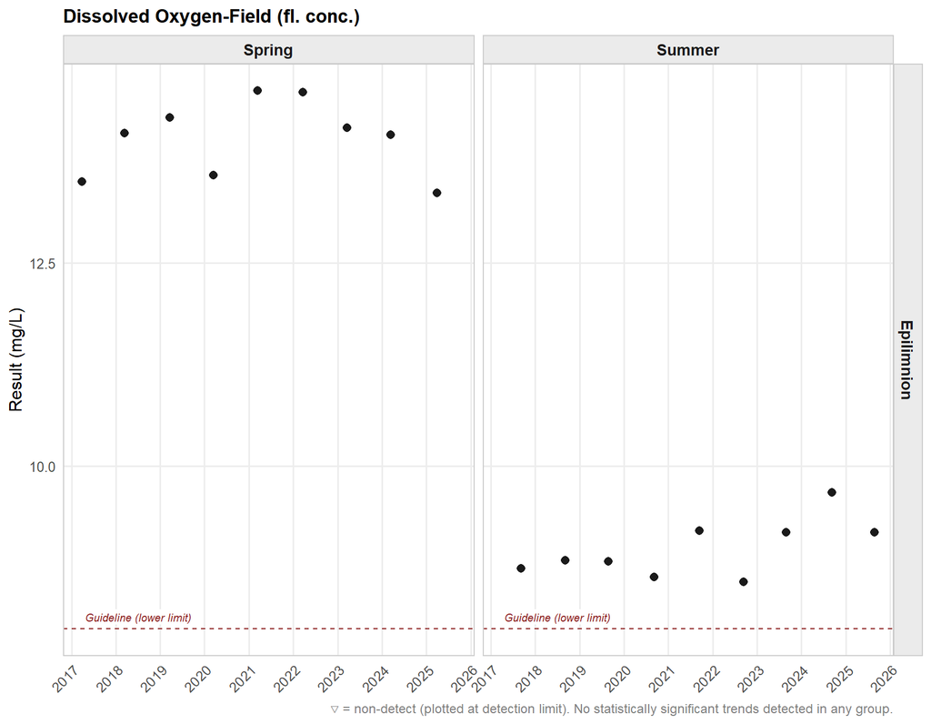

**▶ Summary Statistics Table**

**Lake Report**

Dissolved Oxygen-Field (fl. conc.) (mg/L)

| N | Min<sup>1</sup> | 10th %ile | Median | Mean | 90th %ile | Max |
| --- | --- | --- | --- | --- | --- | --- |
| Epilimnion — Summer |  |  |  |  |  |  |
| 9 | 8.58 | 8.63 | 8.84 | 8.99 | 9.3 | 9.68 |
| Epilimnion — Spring |  |  |  |  |  |  |
| 9 | 13.4 | 13.5 | 14.1 | 14 | 14.6 | 14.6 |

<sup>1</sup> < indicates non-detect; value shown is the detection limit.

##### Extinction Depth (len.)

—

No simple [BC Aquatic Life Guideline](https://www2.gov.bc.ca/gov/content?id=044DD64C7E24415D83D07430964113C9) available for this parameter

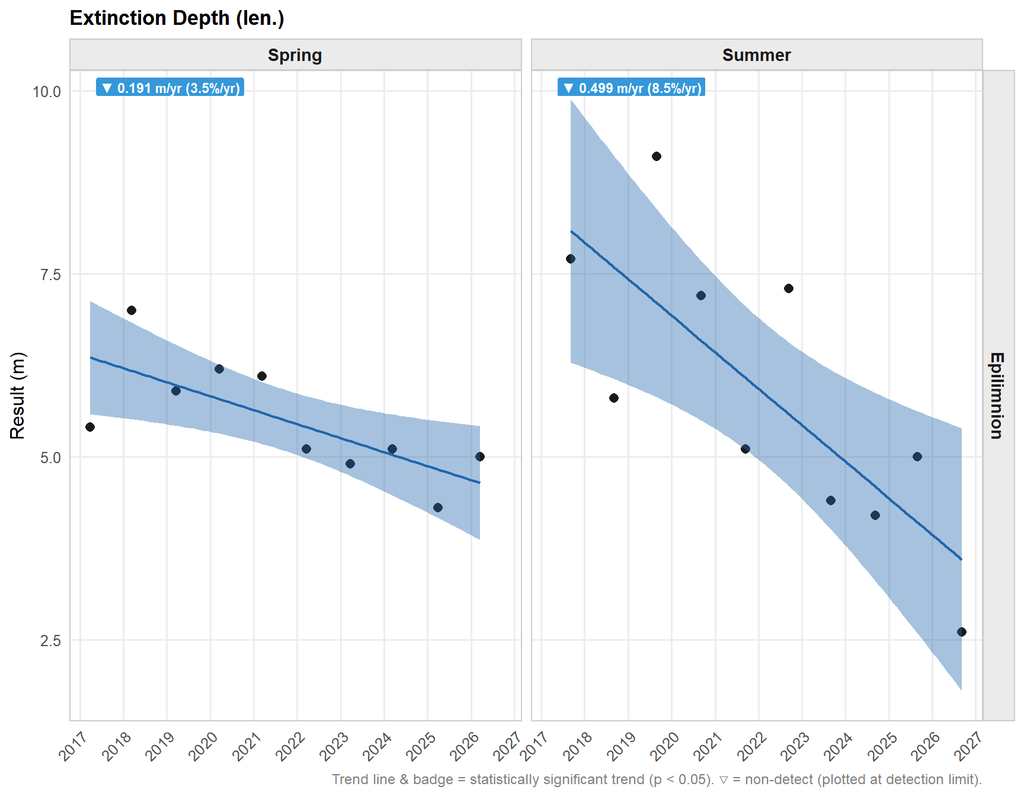

**▶ Summary Statistics Table**

**Lake Report**

Extinction Depth (len.) (m)

| N | Min<sup>1</sup> | 10th %ile | Median | Mean | 90th %ile | Max |
| --- | --- | --- | --- | --- | --- | --- |
| Epilimnion — Summer |  |  |  |  |  |  |
| 10 | 2.6 | 4.04 | 5.45 | 5.84 | 7.84 | 9.1 |
| Epilimnion — Spring |  |  |  |  |  |  |
| 10 | 4.3 | 4.84 | 5.25 | 5.5 | 6.28 | 7 |

<sup>1</sup> < indicates non-detect; value shown is the detection limit.

##### pH-Field (acidity)

—

No simple [BC Aquatic Life Guideline](https://www2.gov.bc.ca/gov/content?id=044DD64C7E24415D83D07430964113C9) available for this parameter

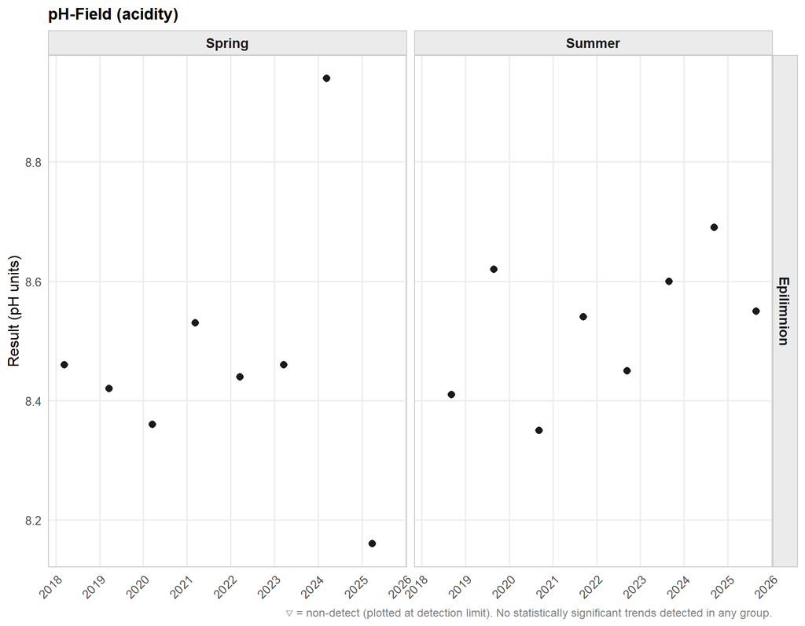

**▶ Summary Statistics Table**

**Lake Report**

pH-Field (acidity) (pH units)

| N | Min<sup>1</sup> | 10th %ile | Median | Mean | 90th %ile | Max |
| --- | --- | --- | --- | --- | --- | --- |
| Epilimnion — Summer |  |  |  |  |  |  |
| 8 | 8.35 | 8.39 | 8.54 | 8.53 | 8.64 | 8.69 |
| Epilimnion — Spring |  |  |  |  |  |  |
| 8 | 8.16 | 8.3 | 8.45 | 8.47 | 8.65 | 8.94 |

<sup>1</sup> < indicates non-detect; value shown is the detection limit.

##### Specific Conductivity-Field (elec. cond.)

—

No simple [BC Aquatic Life Guideline](https://www2.gov.bc.ca/gov/content?id=044DD64C7E24415D83D07430964113C9) available for this parameter

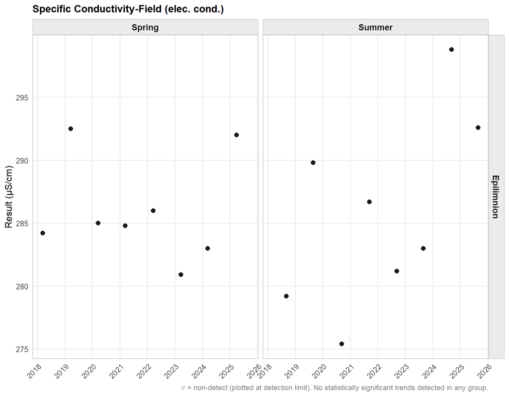

**▶ Summary Statistics Table**

**Lake Report**

Specific Conductivity-Field (elec. cond.) (µS/cm)

| N | Min<sup>1</sup> | 10th %ile | Median | Mean | 90th %ile | Max |
| --- | --- | --- | --- | --- | --- | --- |
| Epilimnion — Summer |  |  |  |  |  |  |
| 8 | 275 | 278 | 285 | 286 | 294 | 299 |
| Epilimnion — Spring |  |  |  |  |  |  |
| 8 | 281 | 282 | 285 | 286 | 292 | 292 |

<sup>1</sup> < indicates non-detect; value shown is the detection limit.

##### Temperature-Field (temp.)

—

No simple [BC Aquatic Life Guideline](https://www2.gov.bc.ca/gov/content?id=044DD64C7E24415D83D07430964113C9) available for this parameter

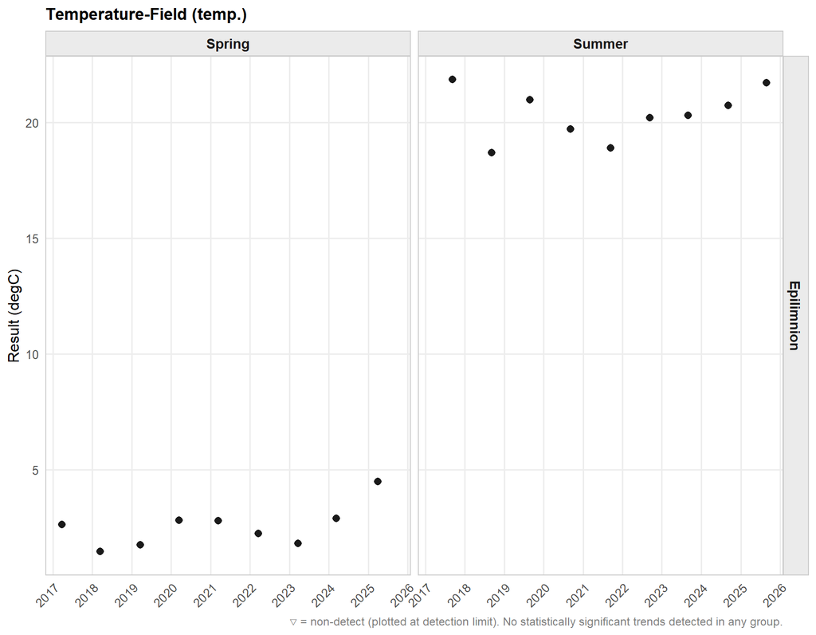

**▶ Summary Statistics Table**

**Lake Report**

Temperature-Field (temp.) (degC)

| N | Min<sup>1</sup> | 10th %ile | Median | Mean | 90th %ile | Max |
| --- | --- | --- | --- | --- | --- | --- |
| Epilimnion — Summer |  |  |  |  |  |  |
| 9 | 18.7 | 18.9 | 20.3 | 20.3 | 21.7 | 21.8 |
| Epilimnion — Spring |  |  |  |  |  |  |
| 9 | 1.47 | 1.7 | 2.64 | 2.55 | 3.22 | 4.49 |

<sup>1</sup> < indicates non-detect; value shown is the detection limit.

#### **General**

##### Carbon Dissolved Organic (fl. conc.)

—

No simple [BC Aquatic Life Guideline](https://www2.gov.bc.ca/gov/content?id=044DD64C7E24415D83D07430964113C9) available for this parameter

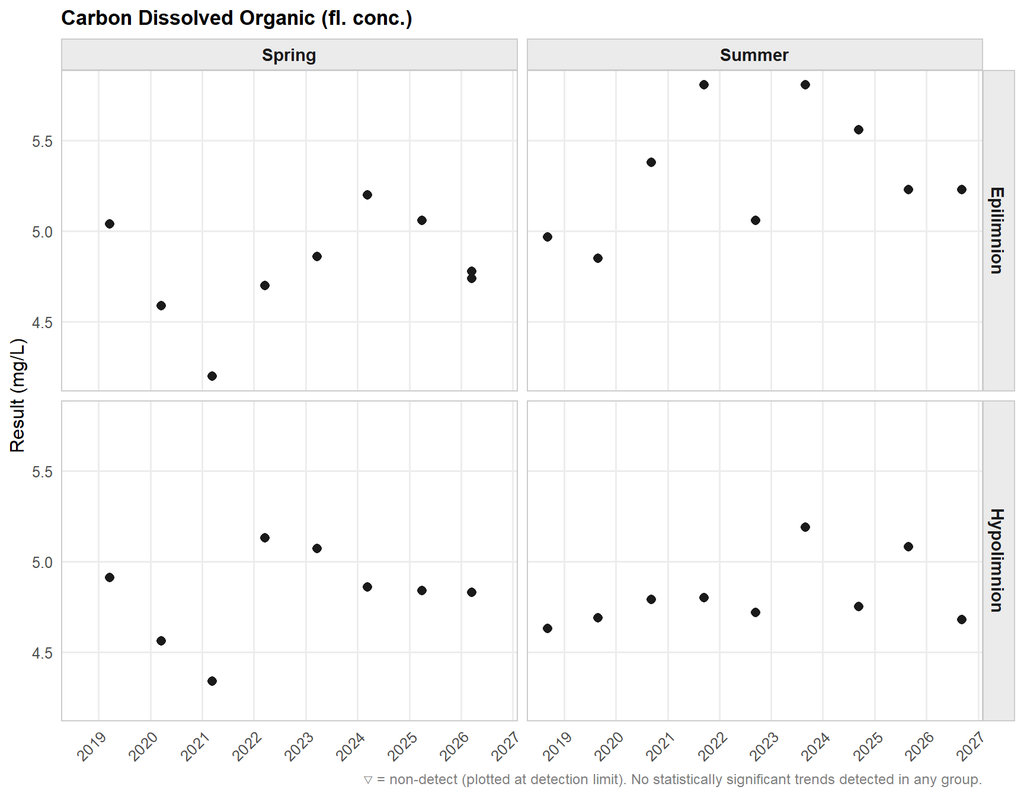

**▶ Summary Statistics Table**

**Lake Report**

Carbon Dissolved Organic (fl. conc.) (mg/L)

| N | Min<sup>1</sup> | 10th %ile | Median | Mean | 90th %ile | Max |
| --- | --- | --- | --- | --- | --- | --- |
| Hypolimnion — Summer |  |  |  |  |  |  |
| 9 | 4.63 | 4.67 | 4.75 | 4.81 | 5.1 | 5.19 |
| Hypolimnion — Spring |  |  |  |  |  |  |
| 8 | 4.34 | 4.49 | 4.85 | 4.82 | 5.09 | 5.13 |
| Epilimnion — Summer |  |  |  |  |  |  |
| 9 | 4.85 | 4.95 | 5.23 | 5.32 | 5.81 | 5.81 |
| Epilimnion — Spring |  |  |  |  |  |  |
| 9 | 4.2 | 4.51 | 4.78 | 4.8 | 5.09 | 5.2 |

<sup>1</sup> < indicates non-detect; value shown is the detection limit.

##### Carbon Total Organic (fl. conc.)

—

No simple [BC Aquatic Life Guideline](https://www2.gov.bc.ca/gov/content?id=044DD64C7E24415D83D07430964113C9) available for this parameter

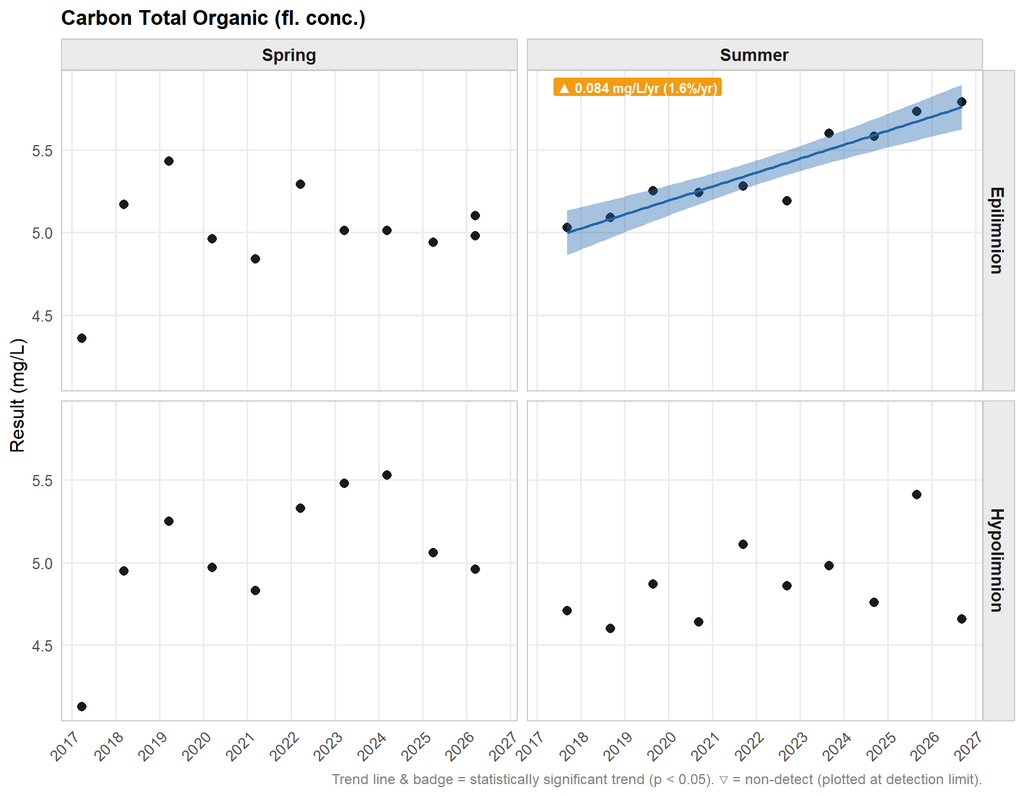

**▶ Summary Statistics Table**

**Lake Report**

Carbon Total Organic (fl. conc.) (mg/L)

| N | Min<sup>1</sup> | 10th %ile | Median | Mean | 90th %ile | Max |
| --- | --- | --- | --- | --- | --- | --- |
| Hypolimnion — Summer |  |  |  |  |  |  |
| 10 | 4.6 | 4.64 | 4.81 | 4.86 | 5.14 | 5.41 |
| Hypolimnion — Spring |  |  |  |  |  |  |
| 10 | 4.13 | 4.76 | 5.01 | 5.05 | 5.48 | 5.53 |
| Epilimnion — Summer |  |  |  |  |  |  |
| 10 | 5.03 | 5.08 | 5.26 | 5.38 | 5.74 | 5.79 |
| Epilimnion — Spring |  |  |  |  |  |  |
| 11 | 4.36 | 4.84 | 5.01 | 5.01 | 5.29 | 5.43 |

<sup>1</sup> < indicates non-detect; value shown is the detection limit.

##### Chlorophyll A (fl. conc.)

—

No simple [BC Aquatic Life Guideline](https://www2.gov.bc.ca/gov/content?id=044DD64C7E24415D83D07430964113C9) available for this parameter

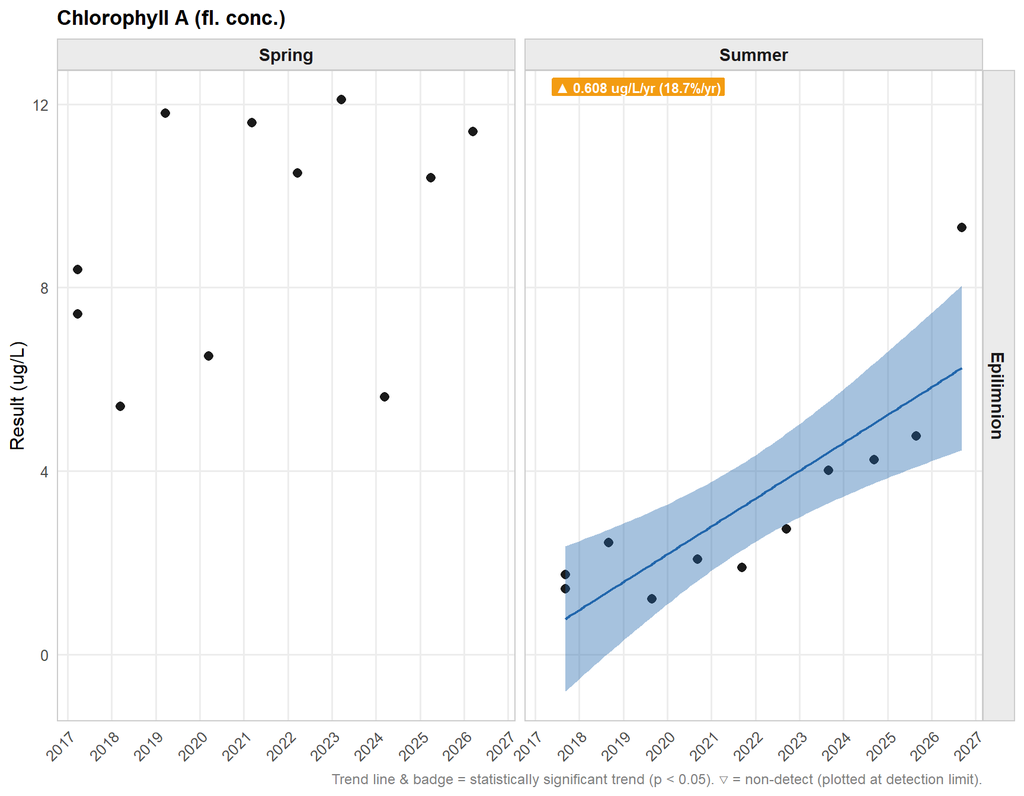

**▶ Summary Statistics Table**

**Lake Report**

Chlorophyll A (fl. conc.) (ug/L)

| N | Min<sup>1</sup> | 10th %ile | Median | Mean | 90th %ile | Max |
| --- | --- | --- | --- | --- | --- | --- |
| Epilimnion — Summer |  |  |  |  |  |  |
| 11 | 1.21 | 1.43 | 2.44 | 3.26 | 4.76 | 9.31 |
| Epilimnion — Spring |  |  |  |  |  |  |
| 11 | 5.41 | 5.62 | 10.4 | 9.2 | 11.8 | 12.1 |

<sup>1</sup> < indicates non-detect; value shown is the detection limit.

##### pH (acidity)

—

No simple [BC Aquatic Life Guideline](https://www2.gov.bc.ca/gov/content?id=044DD64C7E24415D83D07430964113C9) available for this parameter

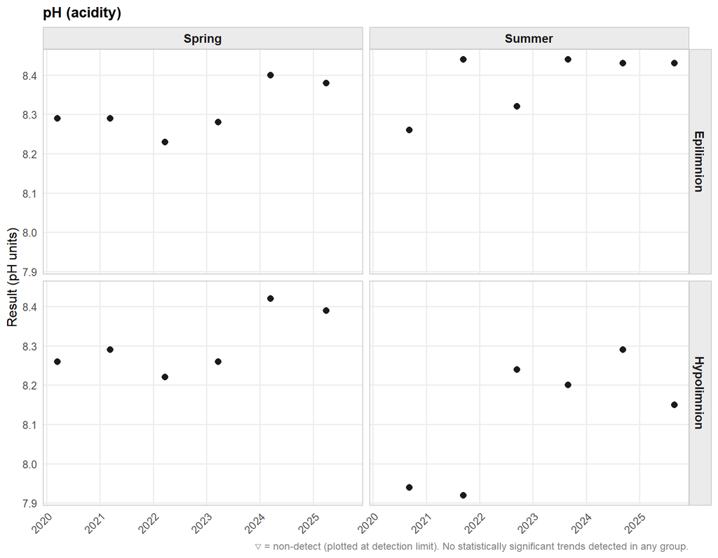

**▶ Summary Statistics Table**

**Lake Report**

pH (acidity) (pH units)

| N | Min<sup>1</sup> | 10th %ile | Median | Mean | 90th %ile | Max |
| --- | --- | --- | --- | --- | --- | --- |
| Hypolimnion — Summer |  |  |  |  |  |  |
| 6 | 7.92 | 7.93 | 8.18 | 8.12 | 8.26 | 8.29 |
| Hypolimnion — Spring |  |  |  |  |  |  |
| 6 | 8.22 | 8.24 | 8.27 | 8.31 | 8.41 | 8.42 |
| Epilimnion — Summer |  |  |  |  |  |  |
| 6 | 8.26 | 8.29 | 8.43 | 8.39 | 8.44 | 8.44 |
| Epilimnion — Spring |  |  |  |  |  |  |
| 6 | 8.23 | 8.25 | 8.29 | 8.31 | 8.39 | 8.4 |

<sup>1</sup> < indicates non-detect; value shown is the detection limit.

##### Specific Conductance (elec. cond.)

—

No simple [BC Aquatic Life Guideline](https://www2.gov.bc.ca/gov/content?id=044DD64C7E24415D83D07430964113C9) available for this parameter

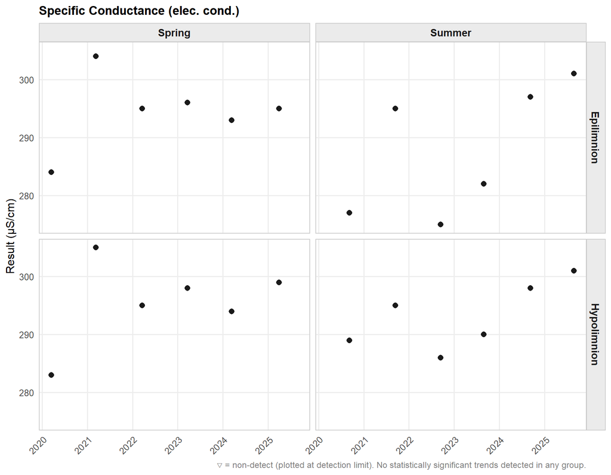

**▶ Summary Statistics Table**

**Lake Report**

Specific Conductance (elec. cond.) (µS/cm)

| N | Min<sup>1</sup> | 10th %ile | Median | Mean | 90th %ile | Max |
| --- | --- | --- | --- | --- | --- | --- |
| Hypolimnion — Summer |  |  |  |  |  |  |
| 6 | 286 | 288 | 292 | 293 | 300 | 301 |
| Hypolimnion — Spring |  |  |  |  |  |  |
| 6 | 283 | 288 | 296 | 296 | 302 | 305 |
| Epilimnion — Summer |  |  |  |  |  |  |
| 6 | 275 | 276 | 288 | 288 | 299 | 301 |
| Epilimnion — Spring |  |  |  |  |  |  |
| 6 | 284 | 288 | 295 | 294 | 300 | 304 |

<sup>1</sup> < indicates non-detect; value shown is the detection limit.

##### Turbidity (turb.)

—

No simple [BC Aquatic Life Guideline](https://www2.gov.bc.ca/gov/content?id=044DD64C7E24415D83D07430964113C9) available for this parameter

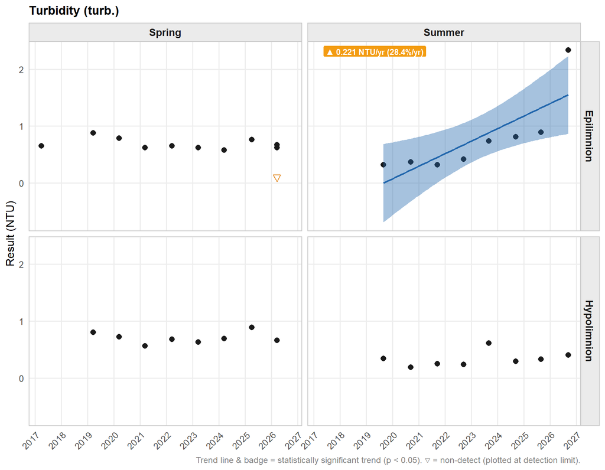

**▶ Summary Statistics Table**

**Lake Report**

Turbidity (turb.) (NTU)

| N | Min<sup>1</sup> | 10th %ile | Median | Mean | 90th %ile | Max |
| --- | --- | --- | --- | --- | --- | --- |
| Hypolimnion — Summer |  |  |  |  |  |  |
| 8 | 0.19 | 0.225 | 0.31 | 0.331 | 0.463 | 0.61 |
| Hypolimnion — Spring |  |  |  |  |  |  |
| 8 | 0.56 | 0.609 | 0.685 | 0.704 | 0.827 | 0.89 |
| Epilimnion — Summer |  |  |  |  |  |  |
| 8 | 0.32 | 0.32 | 0.58 | 0.776 | 1.32 | 2.34 |
| Epilimnion — Spring |  |  |  |  |  |  |
| 11 | <0.1 | 0.58 | 0.65 | 0.631 | 0.79 | 0.88 |

<sup>1</sup> < indicates non-detect; value shown is the detection limit.

#### **Major Ions**

##### Chloride Dissolved (fl. conc.)

✓

[BC Aquatic Life Guideline](https://www2.gov.bc.ca/gov/content/environment/air-land-water/water/water-quality/water-quality-guidelines/approved-water-quality-guidelines) · Long-term chronic (Upper Limit) Aquatic Life - Freshwater

≤150 mg/L

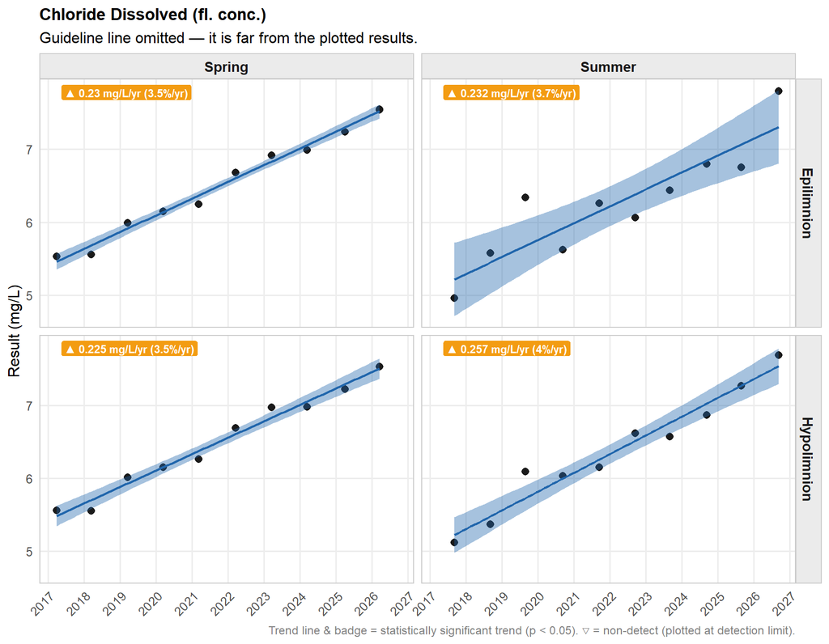

**▶ Summary Statistics Table**

**Lake Report**

Chloride Dissolved (fl. conc.) (mg/L)

| N | Min<sup>1</sup> | 10th %ile | Median | Mean | 90th %ile | Max |
| --- | --- | --- | --- | --- | --- | --- |
| Hypolimnion — Summer |  |  |  |  |  |  |
| 10 | 5.12 | 5.34 | 6.36 | 6.38 | 7.31 | 7.69 |
| Hypolimnion — Spring |  |  |  |  |  |  |
| 10 | 5.55 | 5.56 | 6.48 | 6.49 | 7.25 | 7.53 |
| Epilimnion — Summer |  |  |  |  |  |  |
| 10 | 4.96 | 5.52 | 6.3 | 6.26 | 6.9 | 7.8 |
| Epilimnion — Spring |  |  |  |  |  |  |
| 11 | 5.53 | 5.56 | 6.68 | 6.58 | 7.54 | 7.55 |

<sup>1</sup> < indicates non-detect; value shown is the detection limit.

##### Hardness Total (Total) (fl. conc.)

—

No simple [BC Aquatic Life Guideline](https://www2.gov.bc.ca/gov/content?id=044DD64C7E24415D83D07430964113C9) available for this parameter

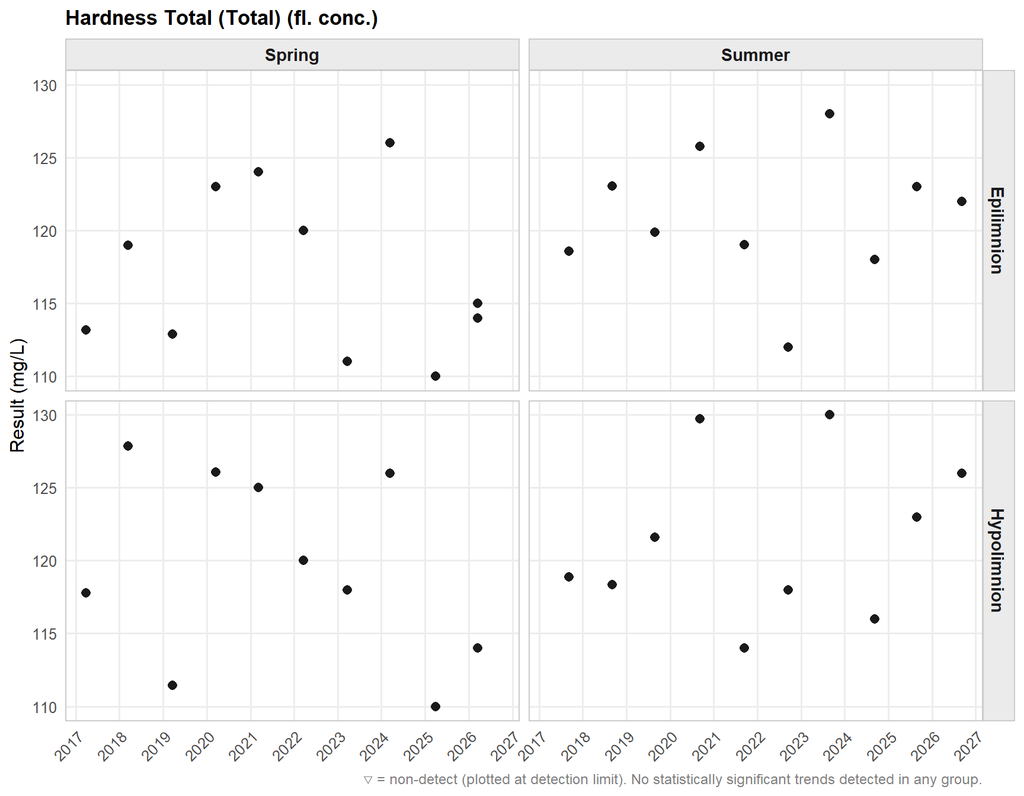

**▶ Summary Statistics Table**

**Lake Report**

Hardness Total (Total) (fl. conc.) (mg/L)

| N | Min<sup>1</sup> | 10th %ile | Median | Mean | 90th %ile | Max |
| --- | --- | --- | --- | --- | --- | --- |
| Hypolimnion — Summer |  |  |  |  |  |  |
| 10 | 114 | 116 | 120 | 122 | 130 | 130 |
| Hypolimnion — Spring |  |  |  |  |  |  |
| 10 | 110 | 111 | 119 | 120 | 126 | 128 |
| Epilimnion — Summer |  |  |  |  |  |  |
| 10 | 112 | 117 | 121 | 121 | 126 | 128 |
| Epilimnion — Spring |  |  |  |  |  |  |
| 11 | 110 | 111 | 115 | 117 | 124 | 126 |

<sup>1</sup> < indicates non-detect; value shown is the detection limit.

##### Sulfate Dissolved (fl. conc.)

—

No simple [BC Aquatic Life Guideline](https://www2.gov.bc.ca/gov/content?id=044DD64C7E24415D83D07430964113C9) available for this parameter

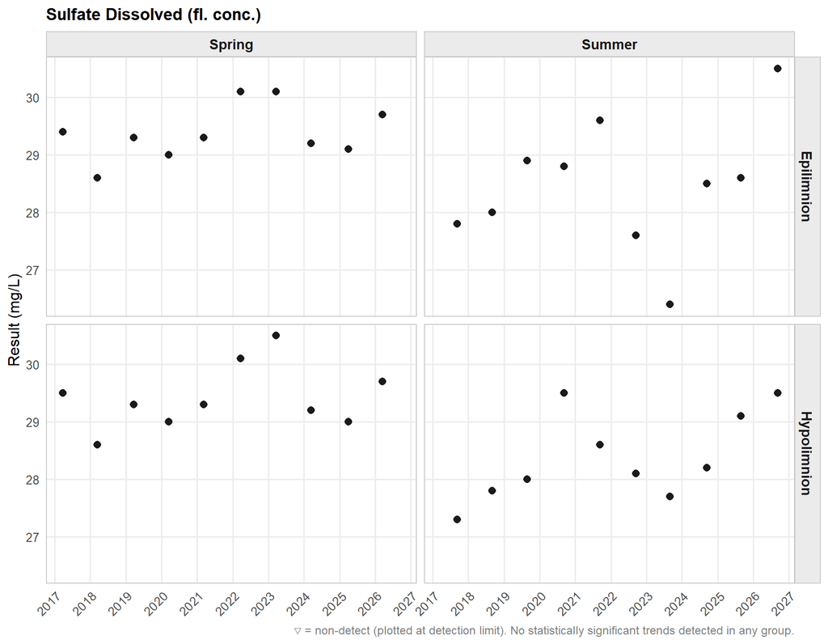

**▶ Summary Statistics Table**

**Lake Report**

Sulfate Dissolved (fl. conc.) (mg/L)

| N | Min<sup>1</sup> | 10th %ile | Median | Mean | 90th %ile | Max |
| --- | --- | --- | --- | --- | --- | --- |
| Hypolimnion — Summer |  |  |  |  |  |  |
| 10 | 27.3 | 27.7 | 28.2 | 28.4 | 29.5 | 29.5 |
| Hypolimnion — Spring |  |  |  |  |  |  |
| 10 | 28.6 | 29 | 29.3 | 29.4 | 30.1 | 30.5 |
| Epilimnion — Summer |  |  |  |  |  |  |
| 10 | 26.4 | 27.5 | 28.6 | 28.5 | 29.7 | 30.5 |
| Epilimnion — Spring |  |  |  |  |  |  |
| 11 | 28.6 | 29 | 29.3 | 29.4 | 30.1 | 30.1 |

<sup>1</sup> < indicates non-detect; value shown is the detection limit.

#### **Nutrients**

##### Nitrate (NO3) Dissolved (fl. conc.)

✓

[BC Aquatic Life Guideline](https://www2.gov.bc.ca/gov/content/environment/air-land-water/water/water-quality/water-quality-guidelines/approved-water-quality-guidelines) · Long-term chronic (Upper Limit) Aquatic Life - Freshwater

≤3 mg/L

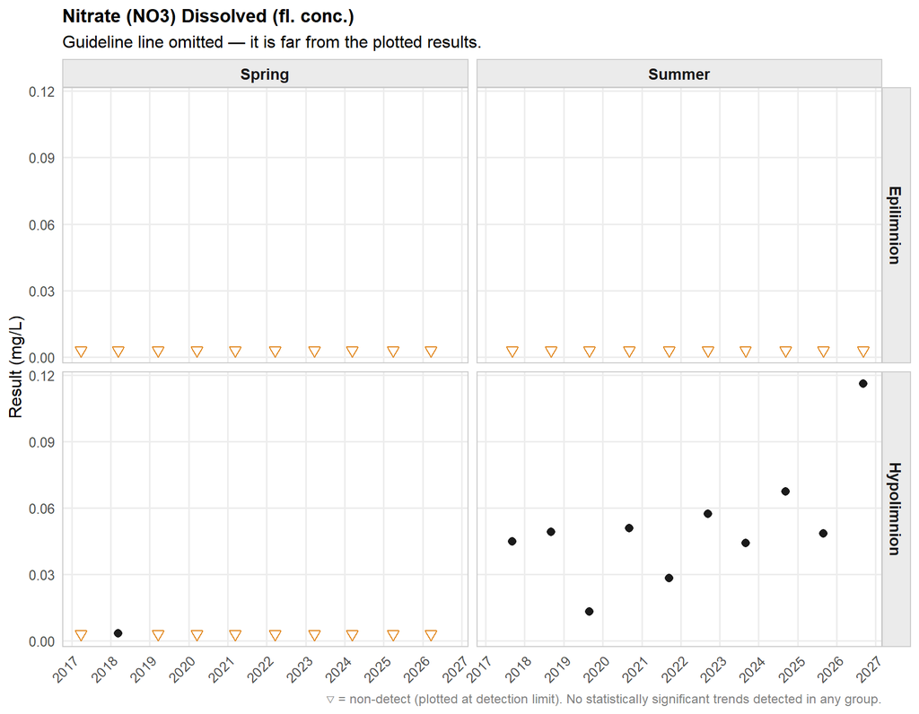

**▶ Summary Statistics Table**

**Lake Report**

Nitrate (NO3) Dissolved (fl. conc.) (mg/L)

| N | Min<sup>1</sup> | 10th %ile | Median | Mean | 90th %ile | Max |
| --- | --- | --- | --- | --- | --- | --- |
| Hypolimnion — Summer |  |  |  |  |  |  |
| 10 | 0.0133 | 0.0267 | 0.0489 | 0.052 | 0.0723 | 0.116 |
| Hypolimnion — Spring |  |  |  |  |  |  |
| 10 | <0.003 | <0.003 | <0.003 | 0.00304 | 0.00304 | 0.0034 |
| Epilimnion — Summer |  |  |  |  |  |  |
| 10 | <0.003 | <0.003 | <0.003 | <0.003 | <0.003 | <0.003 |
| Epilimnion — Spring |  |  |  |  |  |  |
| 11 | <0.003 | <0.003 | <0.003 | <0.003 | <0.003 | <0.003 |

<sup>1</sup> < indicates non-detect; value shown is the detection limit.

##### Nitrate(NO3) + Nitrite(NO2) Dissolved (fl. conc.)

—

No simple [BC Aquatic Life Guideline](https://www2.gov.bc.ca/gov/content?id=044DD64C7E24415D83D07430964113C9) available for this parameter

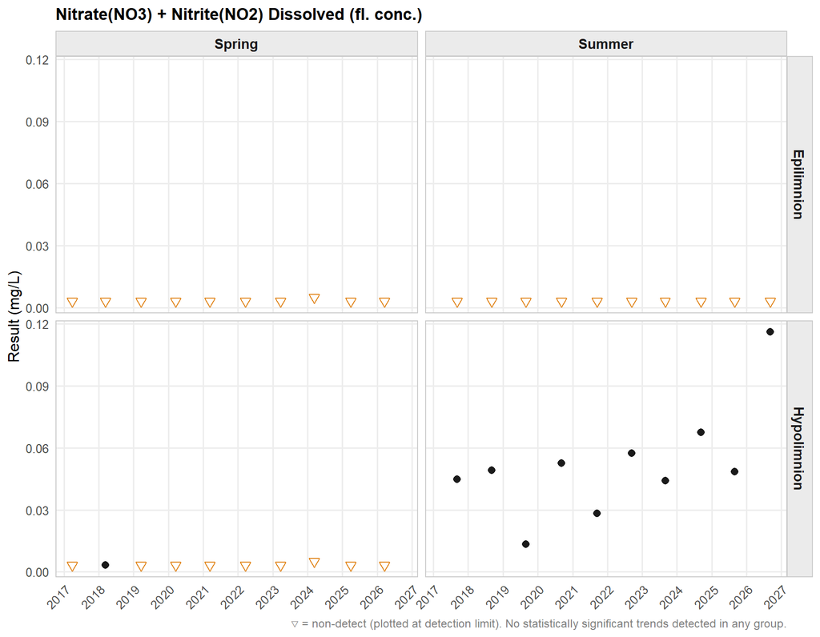

**▶ Summary Statistics Table**

**Lake Report**

Nitrate(NO3) + Nitrite(NO2) Dissolved (fl. conc.) (mg/L)

| N | Min<sup>1</sup> | 10th %ile | Median | Mean | 90th %ile | Max |
| --- | --- | --- | --- | --- | --- | --- |
| Hypolimnion — Summer |  |  |  |  |  |  |
| 10 | 0.0133 | 0.0267 | 0.0489 | 0.0522 | 0.0723 | 0.116 |
| Hypolimnion — Spring |  |  |  |  |  |  |
| 10 | <0.0032 | <0.0032 | <0.0032 | 0.0034 | 0.00356 | 0.005 |
| Epilimnion — Summer |  |  |  |  |  |  |
| 10 | <0.0032 | <0.0032 | <0.0032 | <0.0032 | <0.0032 | <0.0032 |
| Epilimnion — Spring |  |  |  |  |  |  |
| 11 | <0.0032 | <0.0032 | <0.0032 | 0.00336 | <0.0032 | 0.005 |

<sup>1</sup> < indicates non-detect; value shown is the detection limit.

##### Nitrogen - Nitrite Dissolved (NO2) (fl. conc.)

—

No simple [BC Aquatic Life Guideline](https://www2.gov.bc.ca/gov/content?id=044DD64C7E24415D83D07430964113C9) available for this parameter

0.02 - 0.2 mg/L but varies by site conditions

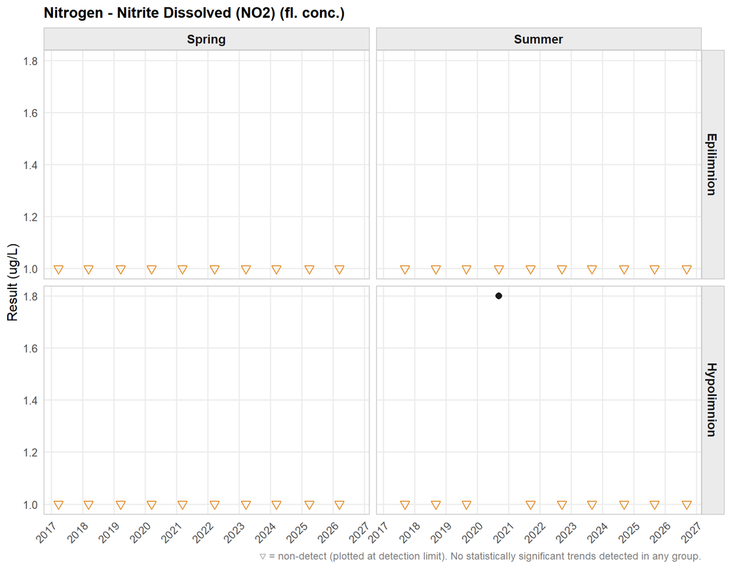

**▶ Summary Statistics Table**

**Lake Report**

Nitrogen - Nitrite Dissolved (NO2) (fl. conc.) (ug/L)

| N | Min<sup>1</sup> | 10th %ile | Median | Mean | 90th %ile | Max |
| --- | --- | --- | --- | --- | --- | --- |
| Hypolimnion — Summer |  |  |  |  |  |  |
| 10 | <1 | <1 | <1 | 1.08 | 1.08 | 1.8 |
| Hypolimnion — Spring |  |  |  |  |  |  |
| 10 | <1 | <1 | <1 | <1 | <1 | <1 |
| Epilimnion — Summer |  |  |  |  |  |  |
| 10 | <1 | <1 | <1 | <1 | <1 | <1 |
| Epilimnion — Spring |  |  |  |  |  |  |
| 11 | <1 | <1 | <1 | <1 | <1 | <1 |

<sup>1</sup> < indicates non-detect; value shown is the detection limit.

##### Nitrogen Ammonia Total (fl. conc.)

—

No simple [BC Aquatic Life Guideline](https://www2.gov.bc.ca/gov/content?id=044DD64C7E24415D83D07430964113C9) available for this parameter

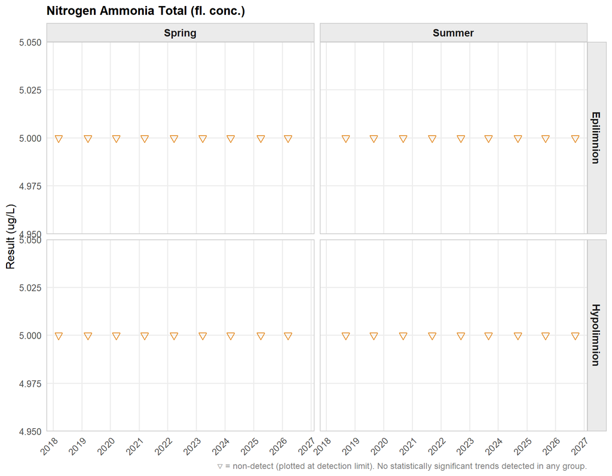

**▶ Summary Statistics Table**

**Lake Report**

Nitrogen Ammonia Total (fl. conc.) (ug/L)

| N | Min<sup>1</sup> | 10th %ile | Median | Mean | 90th %ile | Max |
| --- | --- | --- | --- | --- | --- | --- |
| Hypolimnion — Summer |  |  |  |  |  |  |
| 9 | <5 | <5 | <5 | <5 | <5 | <5 |
| Hypolimnion — Spring |  |  |  |  |  |  |
| 9 | <5 | <5 | <5 | <5 | <5 | <5 |
| Epilimnion — Summer |  |  |  |  |  |  |
| 9 | <5 | <5 | <5 | <5 | <5 | <5 |
| Epilimnion — Spring |  |  |  |  |  |  |
| 10 | <5 | <5 | <5 | <5 | <5 | <5 |

<sup>1</sup> < indicates non-detect; value shown is the detection limit.

##### Nitrogen Kjel.Tot(N) (fl. conc.)

—

No simple [BC Aquatic Life Guideline](https://www2.gov.bc.ca/gov/content?id=044DD64C7E24415D83D07430964113C9) available for this parameter

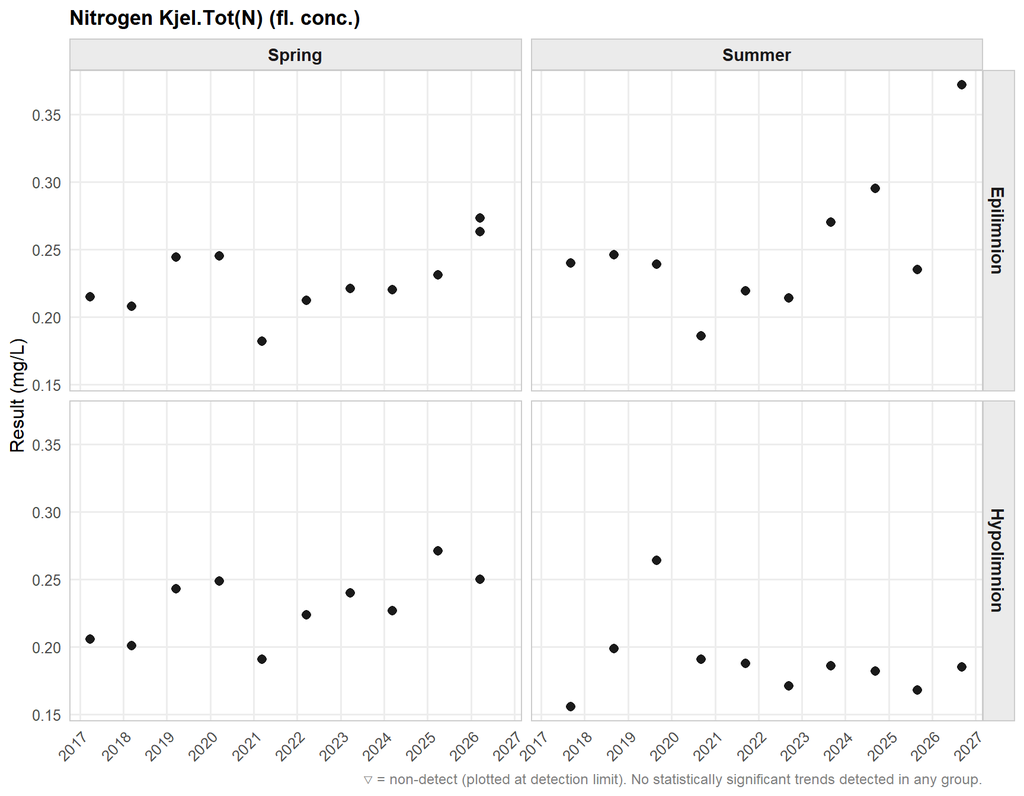

**▶ Summary Statistics Table**

**Lake Report**

Nitrogen Kjel.Tot(N) (fl. conc.) (mg/L)

| N | Min<sup>1</sup> | 10th %ile | Median | Mean | 90th %ile | Max |
| --- | --- | --- | --- | --- | --- | --- |
| Hypolimnion — Summer |  |  |  |  |  |  |
| 10 | 0.156 | 0.167 | 0.186 | 0.189 | 0.206 | 0.264 |
| Hypolimnion — Spring |  |  |  |  |  |  |
| 10 | 0.191 | 0.2 | 0.233 | 0.23 | 0.252 | 0.271 |
| Epilimnion — Summer |  |  |  |  |  |  |
| 10 | 0.186 | 0.211 | 0.24 | 0.252 | 0.303 | 0.372 |
| Epilimnion — Spring |  |  |  |  |  |  |
| 11 | 0.182 | 0.208 | 0.221 | 0.229 | 0.263 | 0.273 |

<sup>1</sup> < indicates non-detect; value shown is the detection limit.

##### Nitrogen Organic-Total (fl. conc.)

—

No simple [BC Aquatic Life Guideline](https://www2.gov.bc.ca/gov/content?id=044DD64C7E24415D83D07430964113C9) available for this parameter

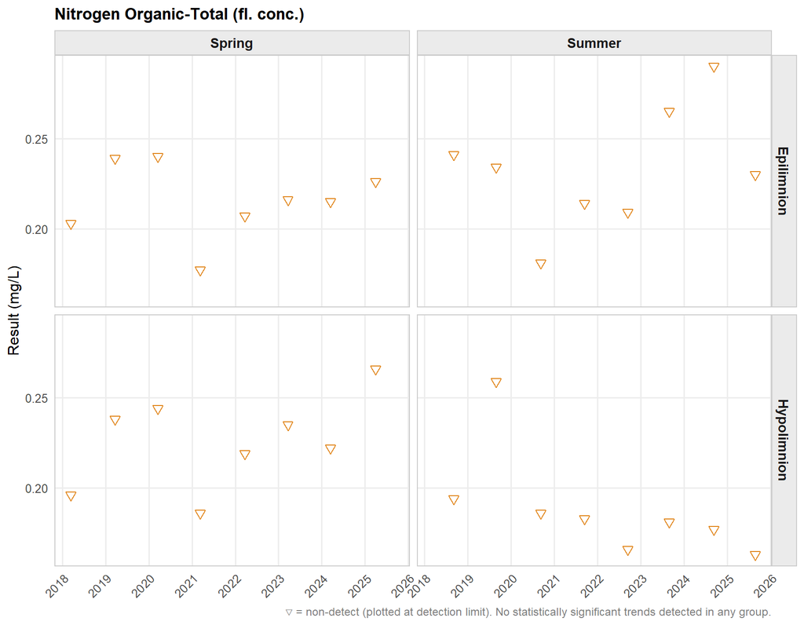

**▶ Summary Statistics Table**

**Lake Report**

Nitrogen Organic-Total (fl. conc.) (mg/L)

| N | Min<sup>1</sup> | 10th %ile | Median | Mean | 90th %ile | Max |
| --- | --- | --- | --- | --- | --- | --- |
| Hypolimnion — Summer |  |  |  |  |  |  |
| 8 | <0.163 | 0.165 | 0.182 | 0.189 | 0.213 | 0.259 |
| Hypolimnion — Spring |  |  |  |  |  |  |
| 8 | 0.186 | 0.193 | 0.228 | 0.226 | 0.251 | 0.266 |
| Epilimnion — Summer |  |  |  |  |  |  |
| 8 | 0.181 | 0.201 | 0.232 | 0.233 | 0.272 | 0.29 |
| Epilimnion — Spring |  |  |  |  |  |  |
| 8 | 0.177 | 0.195 | 0.216 | 0.215 | 0.239 | 0.24 |

<sup>1</sup> < indicates non-detect; value shown is the detection limit.

##### Nitrogen Total (fl. conc.)

—

No simple [BC Aquatic Life Guideline](https://www2.gov.bc.ca/gov/content?id=044DD64C7E24415D83D07430964113C9) available for this parameter

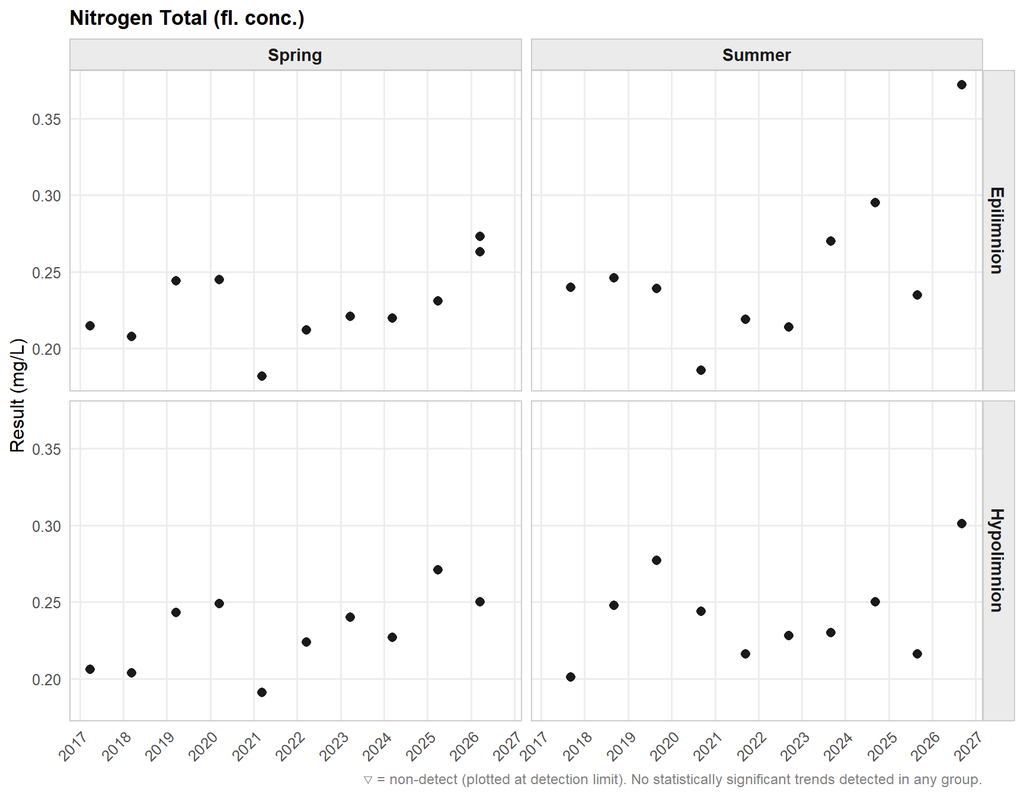

**▶ Summary Statistics Table**

**Lake Report**

Nitrogen Total (fl. conc.) (mg/L)

| N | Min<sup>1</sup> | 10th %ile | Median | Mean | 90th %ile | Max |
| --- | --- | --- | --- | --- | --- | --- |
| Hypolimnion — Summer |  |  |  |  |  |  |
| 10 | 0.201 | 0.215 | 0.237 | 0.241 | 0.279 | 0.301 |
| Hypolimnion — Spring |  |  |  |  |  |  |
| 10 | 0.191 | 0.203 | 0.233 | 0.23 | 0.252 | 0.271 |
| Epilimnion — Summer |  |  |  |  |  |  |
| 10 | 0.186 | 0.211 | 0.24 | 0.252 | 0.303 | 0.372 |
| Epilimnion — Spring |  |  |  |  |  |  |
| 11 | 0.182 | 0.208 | 0.221 | 0.229 | 0.263 | 0.273 |

<sup>1</sup> < indicates non-detect; value shown is the detection limit.

##### Phosphorus Ort.Dis-P (fl. conc.)

—

No simple [BC Aquatic Life Guideline](https://www2.gov.bc.ca/gov/content?id=044DD64C7E24415D83D07430964113C9) available for this parameter

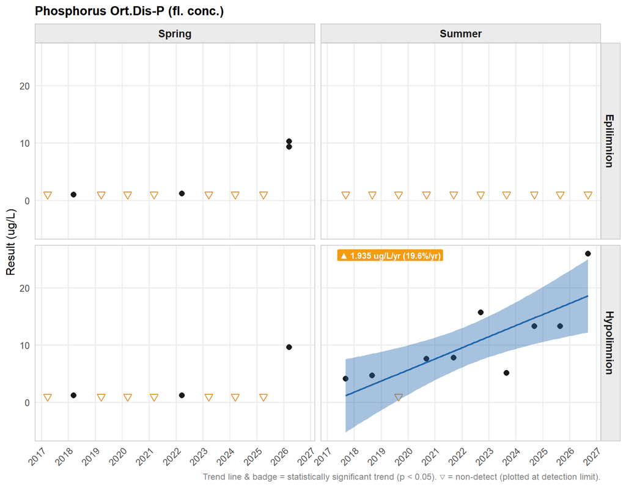

**▶ Summary Statistics Table**

**Lake Report**

Phosphorus Ort.Dis-P (fl. conc.) (ug/L)

| N | Min<sup>1</sup> | 10th %ile | Median | Mean | 90th %ile | Max |
| --- | --- | --- | --- | --- | --- | --- |
| Hypolimnion — Summer |  |  |  |  |  |  |
| 10 | <1 | 3.79 | 7.7 | 9.85 | 16.7 | 25.9 |
| Hypolimnion — Spring |  |  |  |  |  |  |
| 10 | <1 | <1 | <1 | 1.9 | 2.04 | 9.6 |
| Epilimnion — Summer |  |  |  |  |  |  |
| 10 | <1 | <1 | <1 | <1 | <1 | <1 |
| Epilimnion — Spring |  |  |  |  |  |  |
| 11 | <1 | <1 | <1 | 2.62 | 9.3 | 10.3 |

<sup>1</sup> < indicates non-detect; value shown is the detection limit.

##### Phosphorus Total (fl. conc.)

⚠

[BC Aquatic Life Guideline](https://www2.gov.bc.ca/gov/content/environment/air-land-water/water/water-quality/water-quality-guidelines/approved-water-quality-guidelines) · Long-term chronic (Upper Limit) Aquatic Life - Freshwater

≤0.015 mg/L

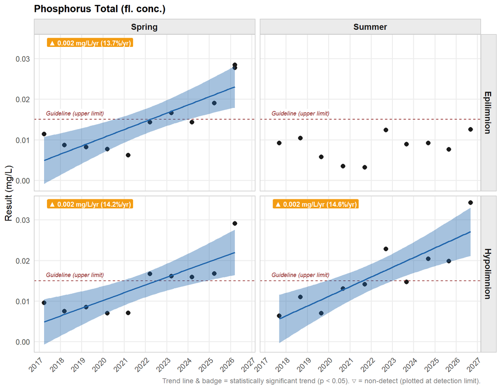

**▶ Summary Statistics Table**

**Lake Report**

Phosphorus Total (fl. conc.) (mg/L)

| N | Min<sup>1</sup> | 10th %ile | Median | Mean | 90th %ile | Max<sup>2</sup> |
| --- | --- | --- | --- | --- | --- | --- |
| Hypolimnion — Summer |  |  |  |  |  |  |
| 10 | 0.0064 | 0.00694 | 0.0144 | 0.0164 | 0.0239 | 0.0342 |
| Hypolimnion — Spring |  |  |  |  |  |  |
| 10 | 0.007 | 0.00709 | 0.0128 | 0.0134 | 0.018 | 0.0291 |
| Epilimnion — Summer |  |  |  |  |  |  |
| 10 | 0.0032 | 0.00347 | 0.00905 | 0.00827 | 0.0124 | 0.0125 |
| Epilimnion — Spring |  |  |  |  |  |  |
| 11 | 0.0062 | 0.0077 | 0.0143 | 0.0148 | 0.0277 | 0.0284 |

<sup>1</sup> < indicates non-detect; value shown is the detection limit.  
<sup>2</sup> Red = this group’s maximum result exceeds the BC Aquatic Life guideline.

##### Phosphorus Total Dissolved (fl. conc.)

—

No simple [BC Aquatic Life Guideline](https://www2.gov.bc.ca/gov/content?id=044DD64C7E24415D83D07430964113C9) available for this parameter

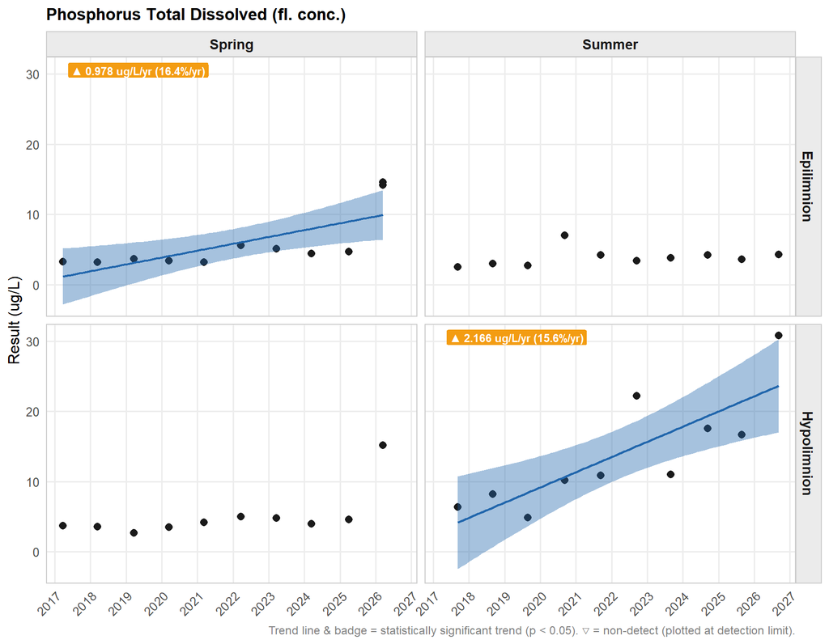

**▶ Summary Statistics Table**

**Lake Report**

Phosphorus Total Dissolved (fl. conc.) (ug/L)

| N | Min<sup>1</sup> | 10th %ile | Median | Mean | 90th %ile | Max |
| --- | --- | --- | --- | --- | --- | --- |
| Hypolimnion — Summer |  |  |  |  |  |  |
| 10 | 4.9 | 6.25 | 11 | 13.9 | 23.1 | 30.8 |
| Hypolimnion — Spring |  |  |  |  |  |  |
| 10 | 2.7 | 3.42 | 4.1 | 5.13 | 6.02 | 15.2 |
| Epilimnion — Summer |  |  |  |  |  |  |
| 10 | 2.5 | 2.68 | 3.7 | 3.87 | 4.57 | 7 |
| Epilimnion — Spring |  |  |  |  |  |  |
| 11 | 3.2 | 3.2 | 4.4 | 5.95 | 14.2 | 14.6 |

<sup>1</sup> < indicates non-detect; value shown is the detection limit.

##### Silica Reactive Diss (fl. conc.)

—

No simple [BC Aquatic Life Guideline](https://www2.gov.bc.ca/gov/content?id=044DD64C7E24415D83D07430964113C9) available for this parameter

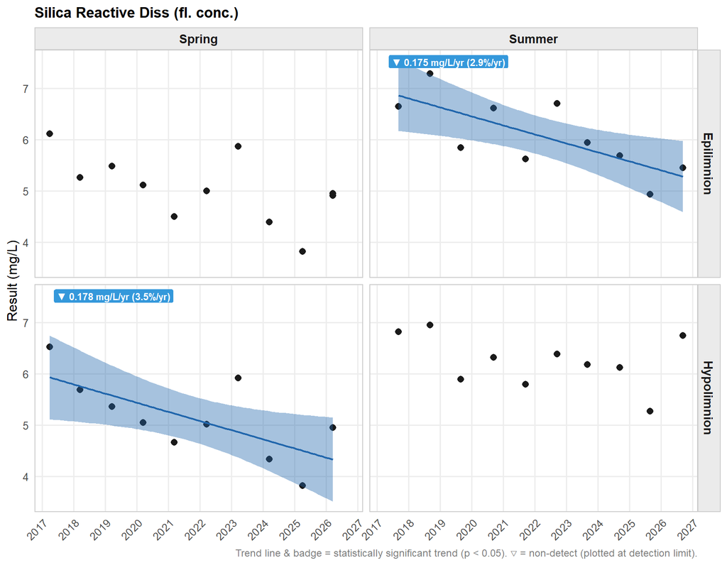

**▶ Summary Statistics Table**

**Lake Report**

Silica Reactive Diss (fl. conc.) (mg/L)

| N | Min<sup>1</sup> | 10th %ile | Median | Mean | 90th %ile | Max |
| --- | --- | --- | --- | --- | --- | --- |
| Hypolimnion — Summer |  |  |  |  |  |  |
| 10 | 5.27 | 5.75 | 6.25 | 6.25 | 6.83 | 6.95 |
| Hypolimnion — Spring |  |  |  |  |  |  |
| 10 | 3.82 | 4.29 | 5.04 | 5.14 | 5.98 | 6.53 |
| Epilimnion — Summer |  |  |  |  |  |  |
| 10 | 4.93 | 5.4 | 5.89 | 6.07 | 6.76 | 7.29 |
| Epilimnion — Spring |  |  |  |  |  |  |
| 11 | 3.82 | 4.39 | 5 | 5.04 | 5.87 | 6.11 |

<sup>1</sup> < indicates non-detect; value shown is the detection limit.

#### **Metals - Total**

##### Aluminum Total (fl. conc.)

—

No simple [BC Aquatic Life Guideline](https://www2.gov.bc.ca/gov/content?id=044DD64C7E24415D83D07430964113C9) available for this parameter

Dependent on hardness, pH, and Dissolved Organic Carbon

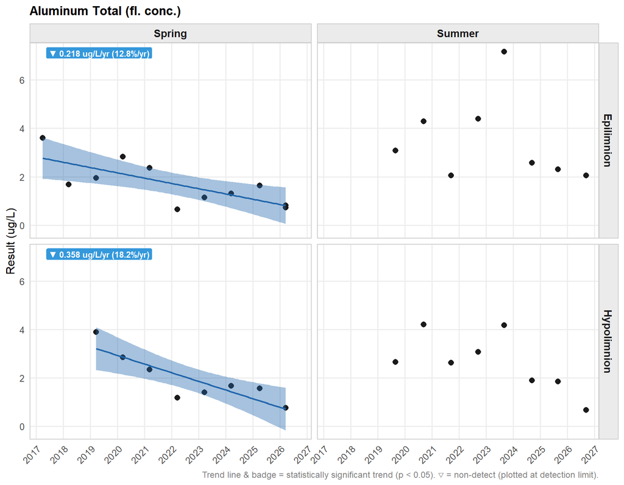

**▶ Summary Statistics Table**

**Lake Report**

Aluminum Total (fl. conc.) (ug/L)

| N | Min<sup>1</sup> | 10th %ile | Median | Mean | 90th %ile | Max |
| --- | --- | --- | --- | --- | --- | --- |
| Hypolimnion — Summer |  |  |  |  |  |  |
| 8 | 0.67 | 1.5 | 2.64 | 2.64 | 4.19 | 4.21 |
| Hypolimnion — Spring |  |  |  |  |  |  |
| 8 | 0.77 | 1.06 | 1.62 | 1.96 | 3.16 | 3.9 |
| Epilimnion — Summer |  |  |  |  |  |  |
| 8 | 2.05 | 2.06 | 2.82 | 3.49 | 5.22 | 7.17 |
| Epilimnion — Spring |  |  |  |  |  |  |
| 11 | 0.65 | 0.73 | 1.63 | 1.7 | 2.83 | 3.6 |

<sup>1</sup> < indicates non-detect; value shown is the detection limit.

##### Antimony Total (fl. conc.)

✓

[BC Aquatic Life Guideline](https://www2.gov.bc.ca/gov/content/environment/air-land-water/water/water-quality/water-quality-guidelines/approved-water-quality-guidelines) · Long-term chronic (Upper Limit) Aquatic Life - Freshwater

≤74 ug/L

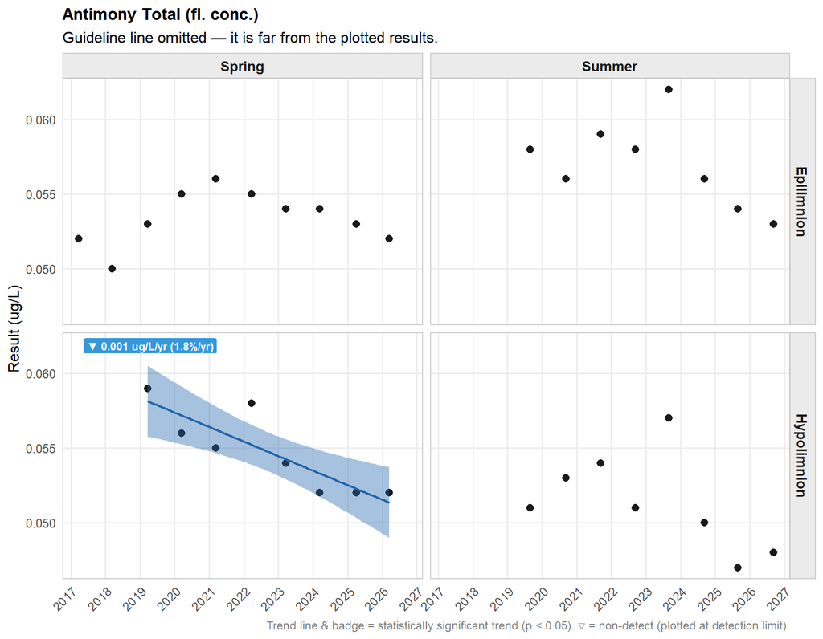

**▶ Summary Statistics Table**

**Lake Report**

Antimony Total (fl. conc.) (ug/L)

| N | Min<sup>1</sup> | 10th %ile | Median | Mean | 90th %ile | Max |
| --- | --- | --- | --- | --- | --- | --- |
| Hypolimnion — Summer |  |  |  |  |  |  |
| 8 | 0.047 | 0.0477 | 0.051 | 0.0514 | 0.0549 | 0.057 |
| Hypolimnion — Spring |  |  |  |  |  |  |
| 8 | 0.052 | 0.052 | 0.0545 | 0.0548 | 0.0583 | 0.059 |
| Epilimnion — Summer |  |  |  |  |  |  |
| 8 | 0.053 | 0.0537 | 0.057 | 0.057 | 0.0599 | 0.062 |
| Epilimnion — Spring |  |  |  |  |  |  |
| 11 | 0.05 | 0.052 | 0.053 | 0.0533 | 0.055 | 0.056 |

<sup>1</sup> < indicates non-detect; value shown is the detection limit.

##### Arsenic Total (fl. conc.)

✓

[BC Aquatic Life Guideline](https://www2.gov.bc.ca/gov/content/environment/air-land-water/water/water-quality/water-quality-guidelines/approved-water-quality-guidelines) · Long-term chronic (Upper Limit) Aquatic Life - Freshwater

≤5 ug/L

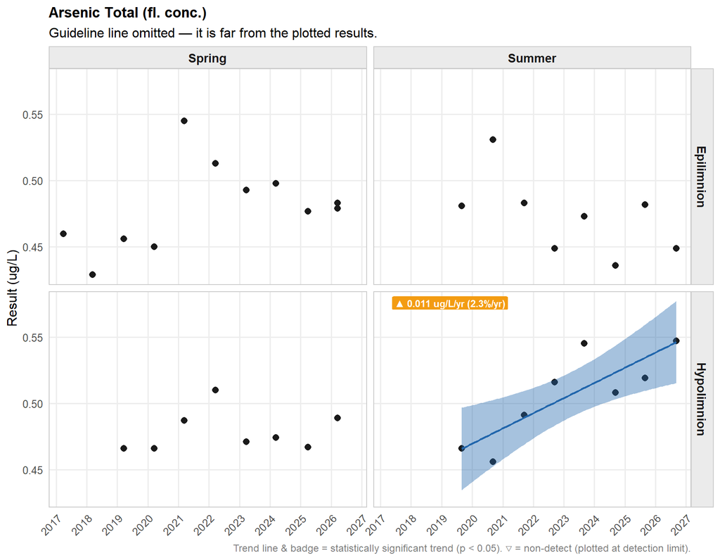

**▶ Summary Statistics Table**

**Lake Report**

Arsenic Total (fl. conc.) (ug/L)

| N | Min<sup>1</sup> | 10th %ile | Median | Mean | 90th %ile | Max |
| --- | --- | --- | --- | --- | --- | --- |
| Hypolimnion — Summer |  |  |  |  |  |  |
| 8 | 0.456 | 0.463 | 0.512 | 0.506 | 0.546 | 0.547 |
| Hypolimnion — Spring |  |  |  |  |  |  |
| 8 | 0.466 | 0.466 | 0.473 | 0.479 | 0.495 | 0.51 |
| Epilimnion — Summer |  |  |  |  |  |  |
| 8 | 0.436 | 0.445 | 0.477 | 0.473 | 0.497 | 0.531 |
| Epilimnion — Spring |  |  |  |  |  |  |
| 11 | 0.429 | 0.45 | 0.479 | 0.48 | 0.513 | 0.545 |

<sup>1</sup> < indicates non-detect; value shown is the detection limit.

##### Barium Total (fl. conc.)

✓

[BC Aquatic Life Guideline](https://www2.gov.bc.ca/gov/content/environment/air-land-water/water/water-quality/water-quality-guidelines/approved-water-quality-guidelines) · Long-term chronic (Upper Limit) Aquatic Life - Freshwater

≤1 mg/L

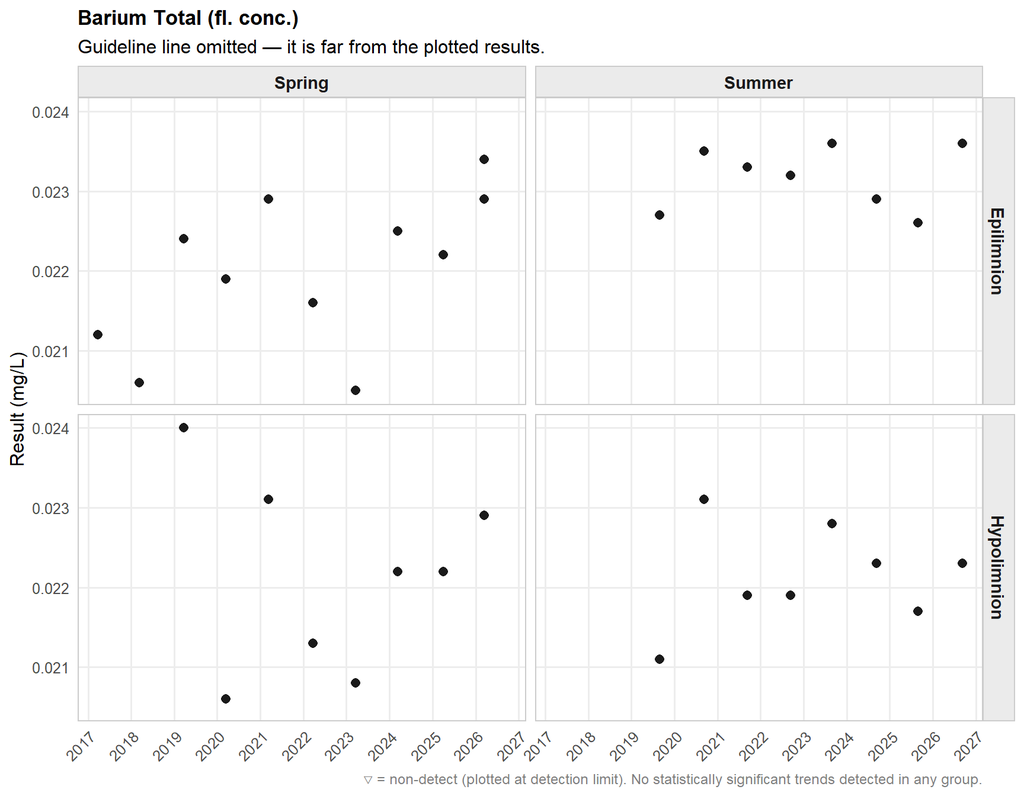

**▶ Summary Statistics Table**

**Lake Report**

Barium Total (fl. conc.) (mg/L)

| N | Min<sup>1</sup> | 10th %ile | Median | Mean | 90th %ile | Max |
| --- | --- | --- | --- | --- | --- | --- |
| Hypolimnion — Summer |  |  |  |  |  |  |
| 8 | 0.0211 | 0.0215 | 0.0221 | 0.0221 | 0.0229 | 0.0231 |
| Hypolimnion — Spring |  |  |  |  |  |  |
| 8 | 0.0206 | 0.0207 | 0.0222 | 0.0221 | 0.0234 | 0.024 |
| Epilimnion — Summer |  |  |  |  |  |  |
| 8 | 0.0226 | 0.0227 | 0.0232 | 0.0232 | 0.0236 | 0.0236 |
| Epilimnion — Spring |  |  |  |  |  |  |
| 11 | 0.0205 | 0.0206 | 0.0222 | 0.022 | 0.0229 | 0.0234 |

<sup>1</sup> < indicates non-detect; value shown is the detection limit.

##### Beryllium Total (fl. conc.)

✓

[BC Aquatic Life Guideline](https://www2.gov.bc.ca/gov/content/environment/air-land-water/water/water-quality/water-quality-guidelines/approved-water-quality-guidelines) · Long-term chronic (Upper Limit) Aquatic Life - Freshwater

≤0.13 ug/L

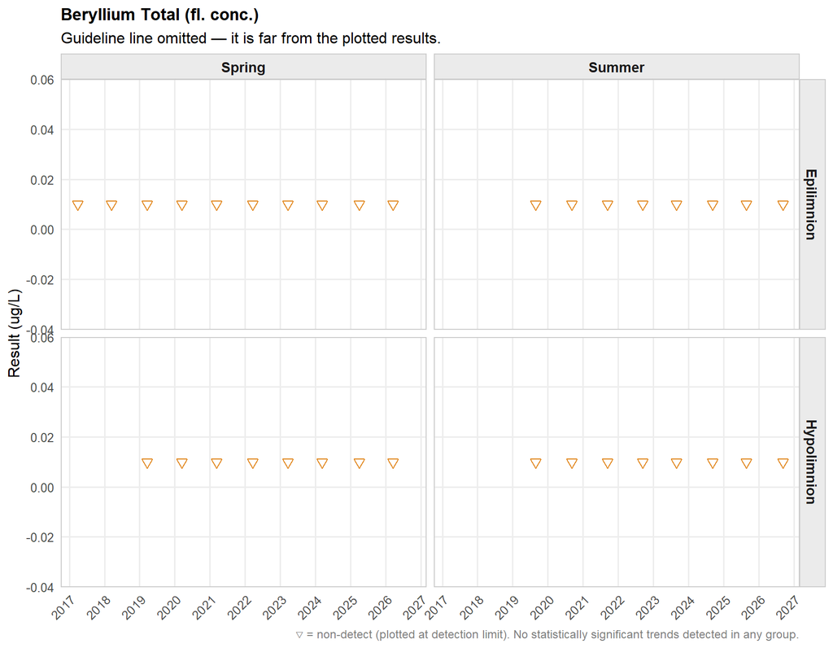

**▶ Summary Statistics Table**

**Lake Report**

Beryllium Total (fl. conc.) (ug/L)

| N | Min<sup>1</sup> | 10th %ile | Median | Mean | 90th %ile | Max |
| --- | --- | --- | --- | --- | --- | --- |
| Hypolimnion — Summer |  |  |  |  |  |  |
| 8 | <0.01 | <0.01 | <0.01 | <0.01 | <0.01 | <0.01 |
| Hypolimnion — Spring |  |  |  |  |  |  |
| 8 | <0.01 | <0.01 | <0.01 | <0.01 | <0.01 | <0.01 |
| Epilimnion — Summer |  |  |  |  |  |  |
| 8 | <0.01 | <0.01 | <0.01 | <0.01 | <0.01 | <0.01 |
| Epilimnion — Spring |  |  |  |  |  |  |
| 11 | <0.01 | <0.01 | <0.01 | <0.01 | <0.01 | <0.01 |

<sup>1</sup> < indicates non-detect; value shown is the detection limit.

##### Bismuth Total (fl. conc.)

—

No simple [BC Aquatic Life Guideline](https://www2.gov.bc.ca/gov/content?id=044DD64C7E24415D83D07430964113C9) available for this parameter

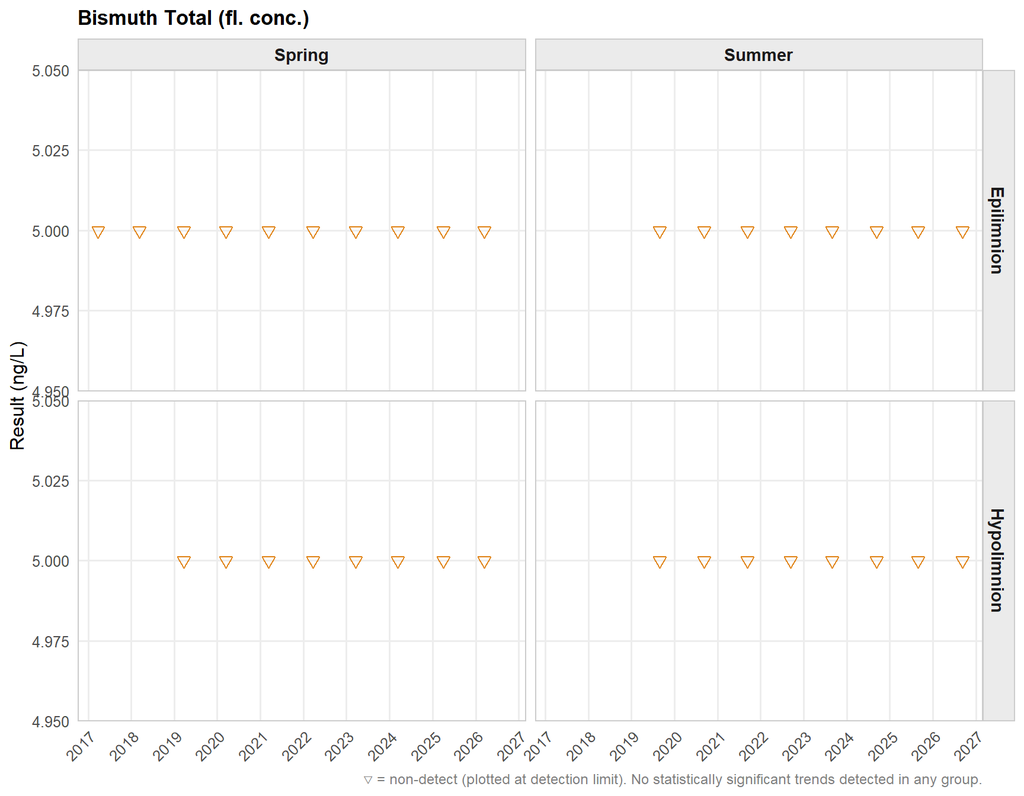

**▶ Summary Statistics Table**

**Lake Report**

Bismuth Total (fl. conc.) (ng/L)

| N | Min<sup>1</sup> | 10th %ile | Median | Mean | 90th %ile | Max |
| --- | --- | --- | --- | --- | --- | --- |
| Hypolimnion — Summer |  |  |  |  |  |  |
| 8 | <5 | <5 | <5 | <5 | <5 | <5 |
| Hypolimnion — Spring |  |  |  |  |  |  |
| 8 | <5 | <5 | <5 | <5 | <5 | <5 |
| Epilimnion — Summer |  |  |  |  |  |  |
| 8 | <5 | <5 | <5 | <5 | <5 | <5 |
| Epilimnion — Spring |  |  |  |  |  |  |
| 11 | <5 | <5 | <5 | <5 | <5 | <5 |

<sup>1</sup> < indicates non-detect; value shown is the detection limit.